# STA130H1 – Fall 2018

Week 5 Practice Problems - Solutions

N. Moon and N. Taback

# Instructions

## What should I bring to tutorial on October 12?

- R output (e.g., plots and explanations) for Question 1 (a)-(e). You can either bring a hardcopy or bring your laptop with the output.

# Tutorial Grading

Tutorial grades will be assigned according to the following marking scheme.

|  | Mark |
| --- | --- |
| Attendance for the entire tutorial | 1 |
| Assigned homework completion<sup>a</sup> | 1 |
| In-class exercises | 4 |
| Total | 6 |

These problems are based on the lesson [Joining Data Frames](https://ntaback.github.io/UofT_STA130/Fall2018/week5/joiningdataframes.html).

# Practice Problems

The file `heroes_information_exer.csv` contains some information on superheroes and `super_hero_powers_exer.csv` conatins some information on powers of superheroes.

The following questions are based on data in `heroes_information.csv` and `super_hero_powers.csv`.

## Question 1

1. Read both data sets `heroes_information.csv` and `super_hero_powers.csv` into R using `read_csv` from the `tidyverse` library. Here is the R code. How may variables and observations are in each data frame?

```r
library(tidyverse)
heroinfo_url <- "https://raw.githubusercontent.com/ntaback/UofT_STA130/master/Fall2018/week5/heroes_information_exer.csv"
heropower_url <- "https://raw.githubusercontent.com/ntaback/UofT_STA130/master/Fall2018/week5/super_hero_powers_exer.csv"

hero_info <- read_csv(heroinfo_url)
hero_power <- read_csv(heropower_url)
glimpse(hero_info)
```

```
## Observations: 487
## Variables: 4
## $ name      <chr> "A-Bomb", "Abe Sapien", "Abin Sur", "Abomination", "...
## $ Alignment <chr> "good", "good", "good", "bad", "bad", "good", "good"...
## $ Weight    <dbl> 441, 65, 90, 441, 122, 88, 61, 81, 104, 108, 90, 90,...
## $ Publisher <chr> "Marvel Comics", "Dark Horse Comics", "DC Comics", "...
```

```r
glimpse(hero_power)
```

```
## Observations: 667
## Variables: 4
## $ name         <chr> "3-D Man", "A-Bomb", "Abe Sapien", "Abin Sur", "A...
## $ Agility      <chr> "True", "False", "True", "False", "False", "False...
## $ Flight       <chr> "False", "False", "False", "False", "False", "Tru...
## $ Marksmanship <chr> "False", "False", "True", "False", "False", "Fals...
```

2. Suggest a key to join the two data frames?

Use `name` as the key since it uniquely identifies observations.

3. What proprotion of superheroes in `heroes_information` also have data in `super_hero_powers`?

```r
inner_join(hero_info, hero_power, by = "name") %>% head()
```

| name | Alignment | Weight | Publisher | Agility | Flight | Marksmanship |
| --- | --- | --- | --- | --- | --- | --- |
| A-Bomb | good | 441 | Marvel Comics | False | False | False |
| Abe Sapien | good | 65 | Dark Horse Comics | True | False | True |
| Abin Sur | good | 90 | DC Comics | False | False | False |
| Abomination | bad | 441 | Marvel Comics | False | False | False |
| Absorbing Man | bad | 122 | Marvel Comics | False | False | False |
| Adam Strange | good | 88 | DC Comics | False | True | True |

```r
inner_join(hero_info, hero_power, by = "name") %>% summarise(n = n())
```

| n |
| --- |
| 460 |

The proportion is 460/487 = 0.94.

4. What is the number of observations, average, median, standard deviation, and inter-quartile range of `weight` for superheroes for each category of marksmanship? (HINT: use the `group_by()` function then `summarise()`)

```r
left_join(hero_info, hero_power, by = "name") %>%
  group_by(Marksmanship) %>%
  summarise(n = n(),
            mean_wt = mean(Weight, na.rm = TRUE),
            sd_wt = sd(Weight, na.rm = TRUE),
            median_wt = median(Weight),
            iqr_wt = IQR(Weight))
```

| Marksmanship | n | mean_wt | sd_wt | median_wt | iqr_wt |
| --- | --- | --- | --- | --- | --- |
| False | 372 | 118.51613 | 111.52529 | 81 | 52.125 |
| True | 88 | 95.88636 | 85.39747 | 83 | 31.500 |
| NA | 27 | 88.00000 | 41.35680 | 79 | 47.500 |

5. Are superheroes with marksmanship thinner compared to those without marksmanship? Create a visualization to compare the distribution of weight between superheroes that have marksmanship and those that don’t have marksmanship. Which distribution has more variability?

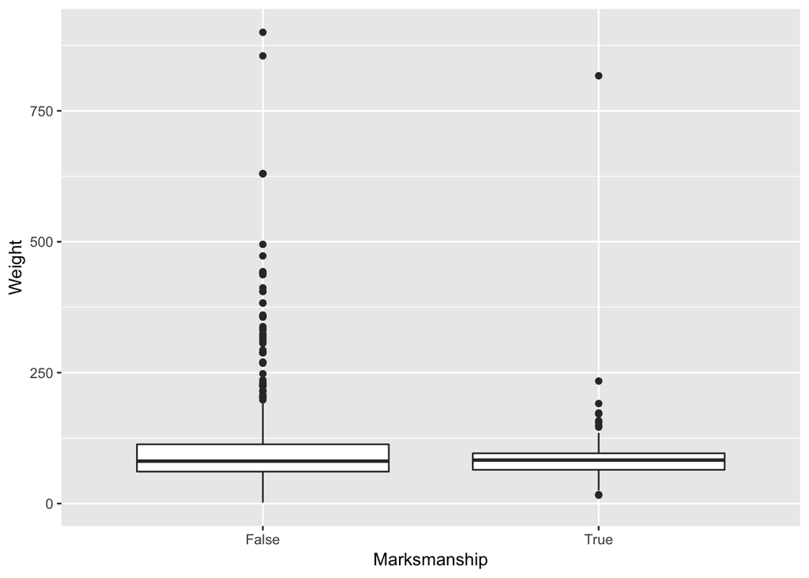

```r
left_join(hero_info, hero_power, by = "name") %>%
  filter(Marksmanship != "NA") %>%
  ggplot(aes(x = Marksmanship, y = Weight)) + geom_boxplot()
```

Superheroes with marksmanship are thinner compared to those without marksmanship. The variability in weight is greater in those without marksmanship compared to those without.